# Linear Models

- Show All Code
- Hide All Code
- View Source

Author

Affiliation

Imane Lattab

The University of Sydney

Published

October 4, 2026

# Cottier et al. 2023 FLE

https://doi.org/10.1167/jov.23.10.8

## Load in Data

```r
# <-----------STAIRCASES-------------->
# 8 staircases (8 repeated measures)
all_staircase_FLEs <- read.csv("/Users/imanelattab/Desktop/Cottier2023/FLE_Raw/all_participants_staircase_FLEs.csv")

# ID, session, and staircase as categorical
all_staircase_FLEs <- all_staircase_FLEs |>
  dplyr::mutate(
    ID = factor(ID),
    session = factor(session),
    staircase = factor(staircase)
  )

# <-----------SESSIONS-------------->
# 2 sessions (2 repeated measures)
myOverallJoV <- read.csv("data/Cottier2023/Cottier2023_2Sessions.csv") # UNZIP!

# ID and session as categorical
myOverallJoV <- myOverallJoV |>
  dplyr::mutate(
    ID = factor(ID),
    session = factor(session)
  )
```

## Sessions

The data analyses that is available on the OSF of the original paper had used sessions as the repeated measure. For the initial presentation of this dataset, we will keep the data in the original format. Later, we will be using staircases as the repeated measure (4 per session, 8 per participant).

### Data Visualisations

**Data (Sessions)**

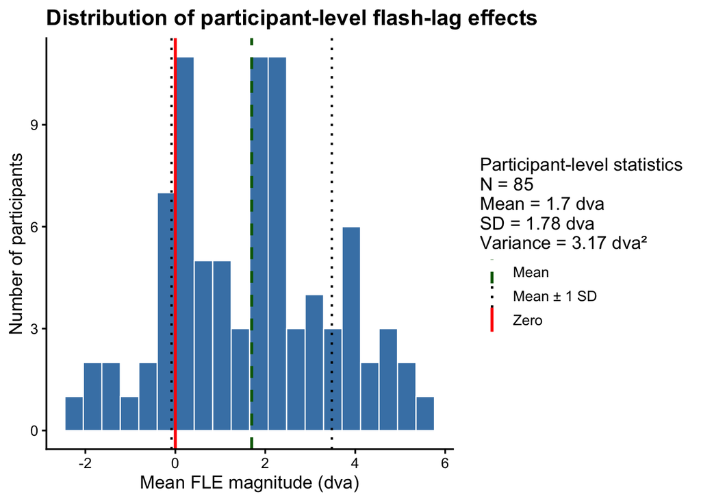

```r
# Calculate one mean FLE magnitude per participant
myOverallJoV_means <- myOverallJoV |>
  group_by(ID) |>
  summarise(
    dva = mean(dva, na.rm = TRUE),
    .groups = "drop"
  )

# Descriptive statistics
fle_stats <- myOverallJoV_means |>
  summarise(
    n = sum(!is.na(dva)),
    mean = mean(dva, na.rm = TRUE),
    sd = sd(dva, na.rm = TRUE),
    variance = var(dva, na.rm = TRUE)
  )

mean_fle <- fle_stats$mean
sd_fle   <- fle_stats$sd

legend_title <- paste0(
  "Participant-level statistics\n",
  "N = ", fle_stats$n, "\n",
  "Mean = ", round(mean_fle, 2), " dva\n",
  "SD = ", round(sd_fle, 2), " dva\n",
  "Variance = ", round(fle_stats$variance, 2), " dva²"
)

ggplot(myOverallJoV_means, aes(x = dva)) +
  geom_histogram(
    bins = 20,
    fill = "steelblue",
    colour = "white",
    linewidth = 0.4
  ) +

  # Zero
  geom_vline(
    aes(xintercept = 0, linetype = "Zero"),
    colour = "red",
    linewidth = 1
  ) +

  # Mean
  geom_vline(
    aes(xintercept = mean_fle, linetype = "Mean"),
    colour = "darkgreen",
    linewidth = 1
  ) +

  # Mean ± 1 SD
  geom_vline(
    aes(
      xintercept = mean_fle - sd_fle,
      linetype = "Mean ± 1 SD"
    ),
    colour = "black",
    linewidth = 0.8
  ) +
  geom_vline(
    aes(
      xintercept = mean_fle + sd_fle,
      linetype = "Mean ± 1 SD"
    ),
    colour = "black",
    linewidth = 0.8
  ) +

  scale_linetype_manual(
    name = legend_title,
    values = c(
      "Zero" = "solid",
      "Mean" = "dashed",
      "Mean ± 1 SD" = "dotted"
    )
  ) +

  labs(
    title = "Distribution of participant-level flash-lag effects",
    x = "Mean FLE magnitude (dva)",
    y = "Number of participants"
  ) +

  theme_classic(base_size = 13) +
  theme(
    legend.position = "right",
    legend.title = element_text(face = "plain"),
    plot.title = element_text(face = "bold")
  )
```

```r
rotation_speed_deg_s <- 180
trajectory_radius_dva <- 12.15

myOverallJoV <- myOverallJoV |>
  mutate(
    # Convert arc length to polar-angle displacement
    FLE_polar_rad = dva / trajectory_radius_dva,
    FLE_polar_deg = FLE_polar_rad * 180 / pi,

    # Convert polar displacement to temporal displacement
    FLE_ms = (FLE_polar_deg / rotation_speed_deg_s) * 1000
  )

myOverallJoV <- myOverallJoV |>
  mutate(
    FLE_ms = dva * 1000 /
      (trajectory_radius_dva * pi)
  )

myOverallJoV_means <- myOverallJoV |>
  group_by(ID) |>
  summarise(
    dva = mean(dva, na.rm = TRUE),
    FLE_ms = mean(FLE_ms, na.rm = TRUE),
    .groups = "drop"
  )
```

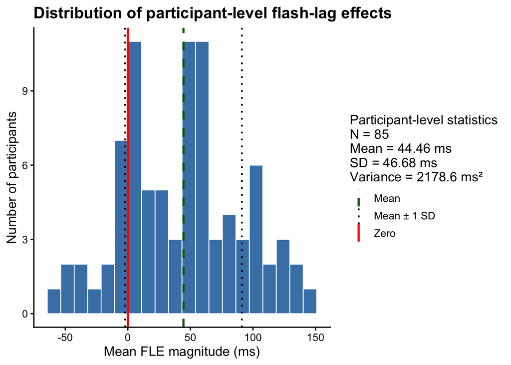

```r
# Calculate one mean FLE magnitude per participant
myOverallJoV_means <- myOverallJoV |>
  group_by(ID) |>
  summarise(
    FLE_ms = mean(FLE_ms, na.rm = TRUE),
    .groups = "drop"
  )

# Descriptive statistics
fle_stats <- myOverallJoV_means |>
  summarise(
    n = sum(!is.na(FLE_ms)),
    mean = mean(FLE_ms, na.rm = TRUE),
    sd = sd(FLE_ms, na.rm = TRUE),
    variance = var(FLE_ms, na.rm = TRUE)
  )

mean_fle <- fle_stats$mean
sd_fle   <- fle_stats$sd

legend_title <- paste0(
  "Participant-level statistics\n",
  "N = ", fle_stats$n, "\n",
  "Mean = ", round(mean_fle, 2), " ms\n",
  "SD = ", round(sd_fle, 2), " ms\n",
  "Variance = ", round(fle_stats$variance, 2), " ms²"
)

ggplot(myOverallJoV_means, aes(x = FLE_ms)) +
  geom_histogram(
    bins = 20,
    fill = "steelblue",
    colour = "white",
    linewidth = 0.4
  ) +

  # Zero
  geom_vline(
    aes(xintercept = 0, linetype = "Zero"),
    colour = "red",
    linewidth = 1
  ) +

  # Mean
  geom_vline(
    aes(xintercept = mean_fle, linetype = "Mean"),
    colour = "darkgreen",
    linewidth = 1
  ) +

  # Mean ± 1 SD
  geom_vline(
    aes(
      xintercept = mean_fle - sd_fle,
      linetype = "Mean ± 1 SD"
    ),
    colour = "black",
    linewidth = 0.8
  ) +
  geom_vline(
    aes(
      xintercept = mean_fle + sd_fle,
      linetype = "Mean ± 1 SD"
    ),
    colour = "black",
    linewidth = 0.8
  ) +

  scale_linetype_manual(
    name = legend_title,
    values = c(
      "Zero" = "solid",
      "Mean" = "dashed",
      "Mean ± 1 SD" = "dotted"
    )
  ) +

  labs(
    title = "Distribution of participant-level flash-lag effects",
    x = "Mean FLE magnitude (ms)",
    y = "Number of participants"
  ) +

  theme_classic(base_size = 13) +
  theme(
    legend.position = "right",
    legend.title = element_text(face = "plain"),
    plot.title = element_text(face = "bold")
  )
```

**FLE (dva) by Participant (Sessions)**

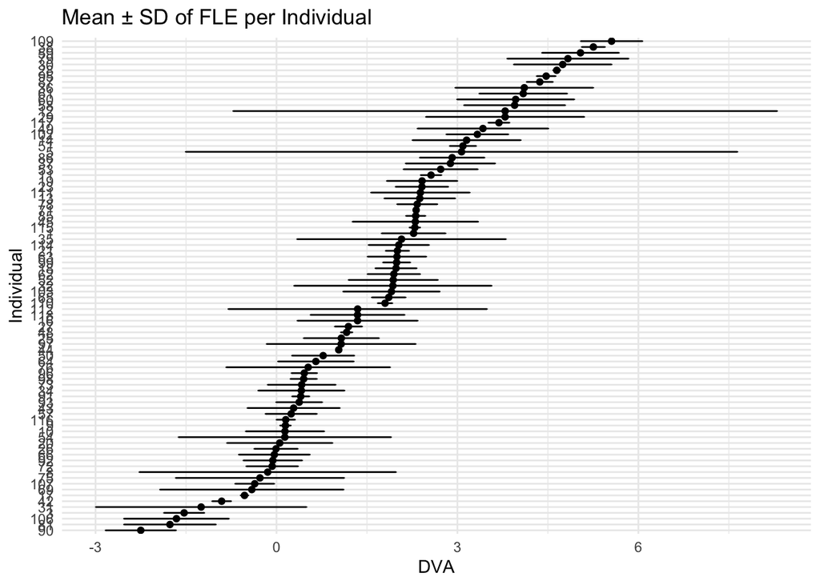

```r
myOverallJoV |>
  group_by(ID) |>
  summarise(
    mean_FLE = mean(dva, na.rm = TRUE),
    sd_FLE = sd(dva, na.rm = TRUE)
  ) |>
  ggplot(aes(x = reorder(ID, mean_FLE), y = mean_FLE)) +
  geom_point() +
  geom_errorbar(aes(ymin = mean_FLE - sd_FLE, ymax = mean_FLE + sd_FLE), width = 0.2) +
  coord_flip() +
  labs(
    title = "Mean ± SD of FLE per Individual",
    x = "Individual",
    y = "DVA"
  ) +
  theme_minimal()
```

**Visualising the ‘Negative’ FLE**

Here, we will use the session data just because we want to have a factor with 3 levels;

- Negative in 1 session
- Negative in both sessions
- Poitive in both sessions

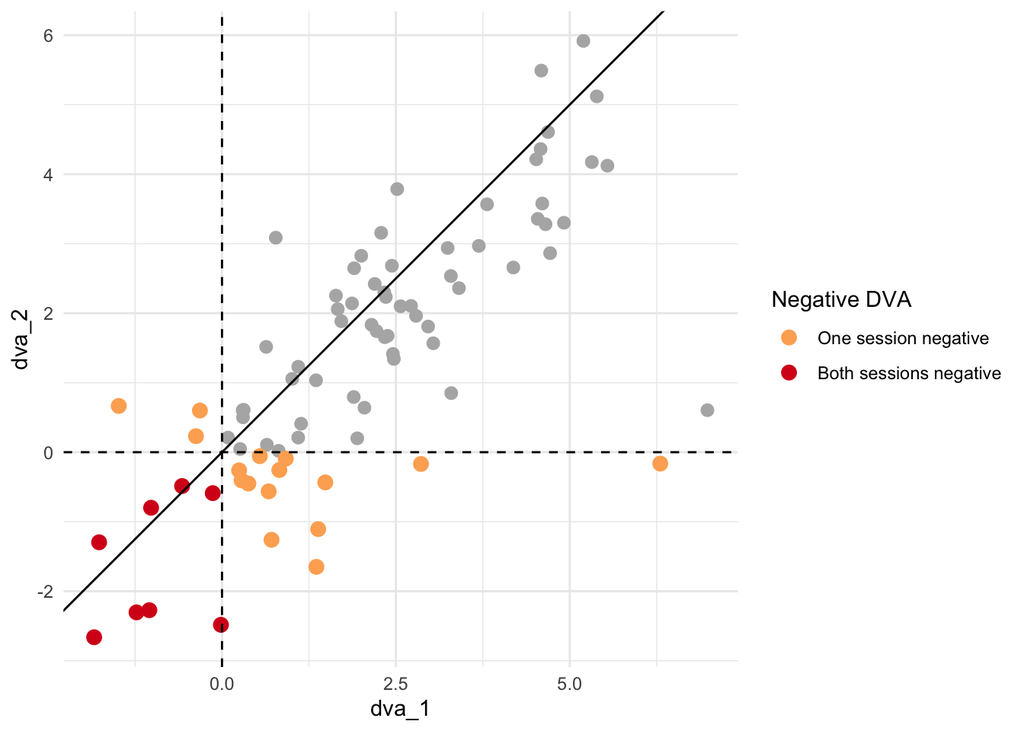

```r
ggplot(wide, aes(x = dva_1, y = dva_2)) +
  geom_point(color = "grey70", size = 2.5) +
  geom_point(
    data = neg_dva,
    aes(x = dva_1, y = dva_2, color = factor(neg_group)),
    size = 3
  ) +
  scale_color_manual(
    values = c("1" = "#FDAE61", "2" = "#D7191C"),
    labels = c("One session negative", "Both sessions negative"),
    name = "Negative DVA"
  ) +
  geom_abline(slope = 1, intercept = 0, color = "black", linetype = "solid") +
  geom_vline(xintercept = 0, linetype = "dashed") +
  geom_hline(yintercept = 0, linetype = "dashed") +
  coord_equal() +
  theme_minimal()
```

```r
neg_dva |>
  arrange(desc(neg_group)) |>
  kable(
    col.names = c("Participant ID", "Session 1 (dva)", "Session 2 (dva)", "Negative Sessions"),
    caption = "Participants with Negative FLE Values"
  ) |>
  kable_styling(full_width = FALSE)
```

Participants with Negative FLE Values

| Participant ID | Session 1 (dva) | Session 2 (dva) | Negative Sessions |
| --- | --- | --- | --- |
| 3 | -1.7668952 | -1.2958962 | 2 |
| 17 | -0.5737393 | -0.4866482 | 2 |
| 31 | -0.0153415 | -2.4829230 | 2 |
| 42 | -1.0193817 | -0.7991153 | 2 |
| 81 | -1.2290867 | -2.3039742 | 2 |
| 90 | -1.8383531 | -2.6619281 | 2 |
| 106 | -1.0449293 | -2.2728295 | 2 |
| 107 | -0.1332053 | -0.5886491 | 2 |
| 5 | 6.3014477 | -0.1639139 | 1 |
| 8 | 1.3573179 | -1.6491856 | 1 |
| 10 | -0.3175941 | 0.5994416 | 1 |
| 20 | 0.6711398 | -0.5635755 | 1 |
| 26 | 0.2459387 | -0.2612225 | 1 |
| 34 | 0.9169011 | -0.0922423 | 1 |
| 43 | 0.8245372 | -0.2561955 | 1 |
| 54 | 1.3828863 | -1.1064723 | 1 |
| 57 | 0.5430828 | -0.0563687 | 1 |
| 66 | 0.3791614 | -0.4507561 | 1 |
| 69 | -1.4843266 | 0.6657629 | 1 |
| 72 | -0.3738531 | 0.2305579 | 1 |
| 75 | 0.7121155 | -1.2601606 | 1 |
| 76 | 1.4849766 | -0.4344168 | 1 |
| 92 | 0.2817979 | -0.4046950 | 1 |
| 112 | 2.8608107 | -0.1690749 | 1 |

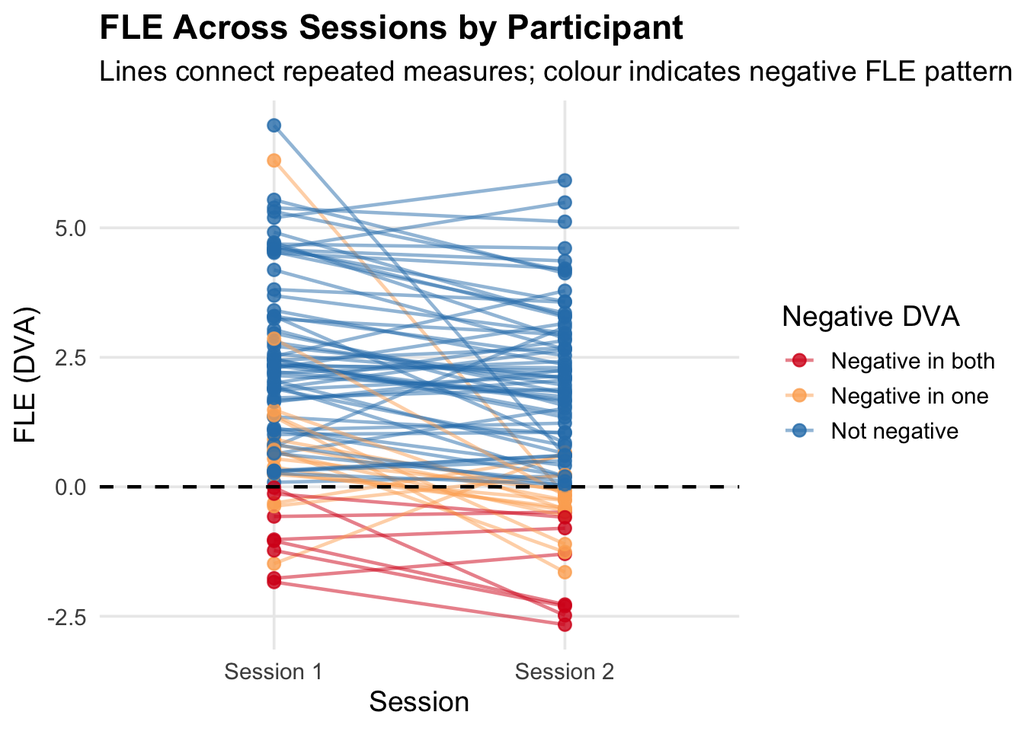

```r
ggplot(long, aes(x = session, y = dva, group = ID, color = neg_group)) +

  # connecting lines
  geom_line(alpha = 0.5, linewidth = 0.8) +

  # points
  geom_point(size = 2.5, alpha = 0.8) +

  # zero reference line
  geom_hline(
    yintercept = 0,
    linetype = "dashed",
    color = "black",
    linewidth = 0.8
  ) +

  scale_color_manual(
    values = c(
      "Not negative"    = "#2C7FB8",
      "Negative in one" = "#FDAE61",
      "Negative in both"= "#D7191C"
    ),
    name = "Negative DVA"
  ) +

  labs(
    title = "FLE Across Sessions by Participant",
    subtitle = "Lines connect repeated measures; colour indicates negative FLE pattern",
    x = "Session",
    y = "FLE (DVA)"
  ) +

  theme_minimal(base_size = 14) +
  theme(
    plot.title = element_text(face = "bold"),
    panel.grid.minor = element_blank()
  )
```

```r
# curious to see how many people have a "smaller/more negative" FLE in session 2
long_dir <- wide |>
  mutate(
    change = case_when(
      dva_2 > dva_1 ~ "Increase",
      dva_2 < dva_1 ~ "Decrease",
      TRUE          ~ "No change"
    )
  ) |>
  pivot_longer(
    cols = c(dva_1, dva_2),
    names_to = "session",
    values_to = "dva"
  ) |>
  mutate(
    session = factor(session,
                     levels = c("dva_1", "dva_2"),
                     labels = c("Session 1", "Session 2"))
  )

# participants where dva "increased" in session 2
p_increase <- long_dir |>
  filter(change == "Increase") |>
  ggplot(aes(x = session, y = dva, group = ID)) +

  geom_line(color = "#2C7FB8", alpha = 0.6, linewidth = 0.9) +
  geom_point(color = "#2C7FB8", size = 2.5, alpha = 0.9) +

  geom_hline(yintercept = 0, linetype = "dashed", color = "black") +

  labs(
    title = "Participants with Increased FLE (Session 2 > Session 1)",
    x = "Session",
    y = "FLE (dva)"
  ) +

  theme_minimal(base_size = 14) +
  theme(
    plot.title = element_text(face = "bold"),
    panel.grid.minor = element_blank()
  )

# participants where dva "decreased" in session 2
p_decrease <- long_dir |>
  filter(change == "Decrease") |>
  ggplot(aes(x = session, y = dva, group = ID)) +

  geom_line(color = "#D7191C", alpha = 0.6, linewidth = 0.9) +
  geom_point(color = "#D7191C", size = 2.5, alpha = 0.9) +

  geom_hline(yintercept = 0, linetype = "dashed", color = "black") +

  labs(
    title = "Participants with Decreased FLE (Session 2 < Session 1)",
    x = "Session",
    y = "FLE (dva)"
  ) +

  theme_minimal(base_size = 14) +
  theme(
    plot.title = element_text(face = "bold"),
    panel.grid.minor = element_blank()
  )
```

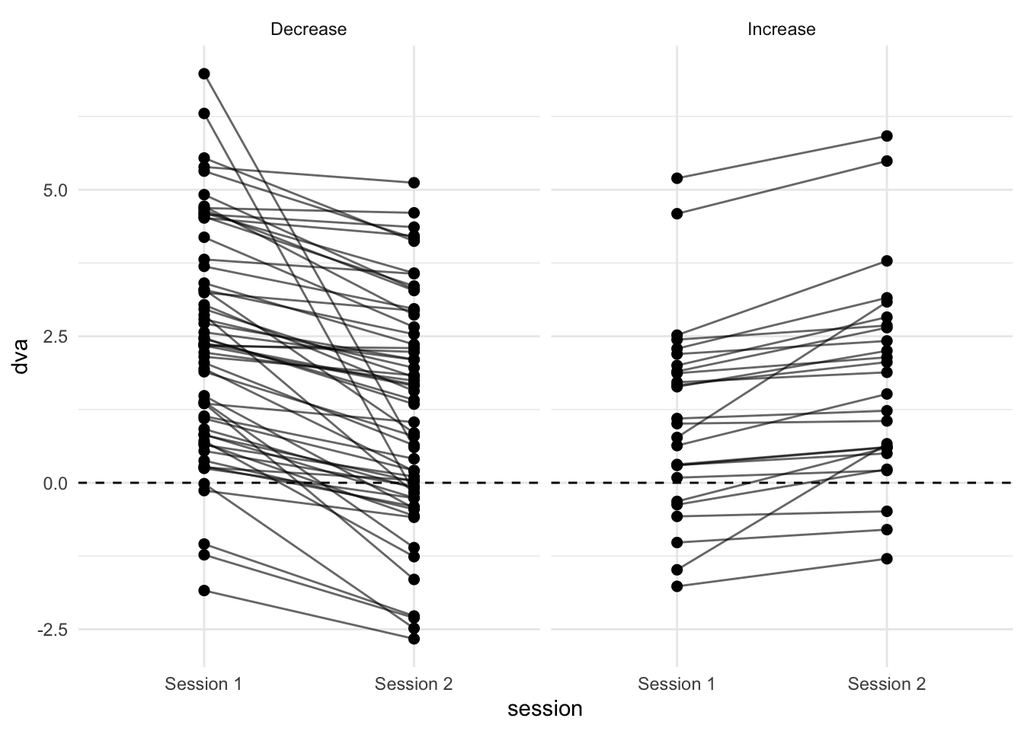

```r
# side by side
ggplot(long_dir |> filter(change != "No change"),
       aes(x = session, y = dva, group = ID)) +
  geom_line(alpha = 0.6) +
  geom_point(size = 2) +
  geom_hline(yintercept = 0, linetype = "dashed") +
  facet_wrap(~change) +
  theme_minimal()
```

```r
# counts
change_summary <- wide |>
  mutate(
    change = case_when(
      dva_2 > dva_1 ~ "Increase",
      dva_2 < dva_1 ~ "Decrease",
      TRUE          ~ "No change"
    )
  ) |>
  count(change) |>
  mutate(
    proportion = n / sum(n),
    percent = round(proportion * 100, 1)
  )

kable(change_summary,
      col.names = c("Change Direction", "Count", "Proportion", "Percent"),
      caption = "Participant Change in FLE from Session 1 to Session 2")
```

Participant Change in FLE from Session 1 to Session 2

| Change Direction | Count | Proportion | Percent |
| --- | --- | --- | --- |
| Decrease | 59 | 0.6941176 | 69.4 |
| Increase | 26 | 0.3058824 | 30.6 |

## Multiple Staircase

We will go back to the 8 staircase data for analyses since it provides us with more repeated measures.

### Data Visualisations

**Dataset (Staircases)**

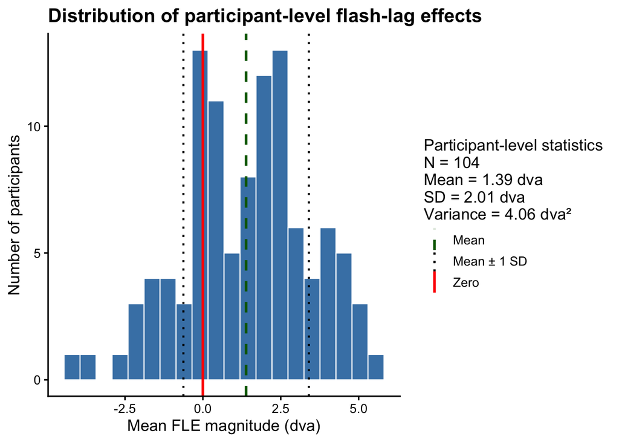

```r
# Calculate one mean FLE magnitude per participant
all_staircase_FLEs_means <- all_staircase_FLEs |>
  group_by(ID) |>
  summarise(
    FLE_dva = mean(FLE_dva, na.rm = TRUE),
    .groups = "drop"
  )

# Descriptive statistics
fle_stats <- all_staircase_FLEs_means |>
  summarise(
    n = sum(!is.na(FLE_dva)),
    mean = mean(FLE_dva, na.rm = TRUE),
    sd = sd(FLE_dva, na.rm = TRUE),
    variance = var(FLE_dva, na.rm = TRUE)
  )

mean_fle <- fle_stats$mean
sd_fle   <- fle_stats$sd

legend_title <- paste0(
  "Participant-level statistics\n",
  "N = ", fle_stats$n, "\n",
  "Mean = ", round(mean_fle, 2), " dva\n",
  "SD = ", round(sd_fle, 2), " dva\n",
  "Variance = ", round(fle_stats$variance, 2), " dva²"
)

ggplot(all_staircase_FLEs_means, aes(x = FLE_dva)) +
  geom_histogram(
    bins = 20,
    fill = "steelblue",
    colour = "white",
    linewidth = 0.4
  ) +

  # Zero
  geom_vline(
    aes(xintercept = 0, linetype = "Zero"),
    colour = "red",
    linewidth = 1
  ) +

  # Mean
  geom_vline(
    aes(xintercept = mean_fle, linetype = "Mean"),
    colour = "darkgreen",
    linewidth = 1
  ) +

  # Mean ± 1 SD
  geom_vline(
    aes(
      xintercept = mean_fle - sd_fle,
      linetype = "Mean ± 1 SD"
    ),
    colour = "black",
    linewidth = 0.8
  ) +
  geom_vline(
    aes(
      xintercept = mean_fle + sd_fle,
      linetype = "Mean ± 1 SD"
    ),
    colour = "black",
    linewidth = 0.8
  ) +

  scale_linetype_manual(
    name = legend_title,
    values = c(
      "Zero" = "solid",
      "Mean" = "dashed",
      "Mean ± 1 SD" = "dotted"
    )
  ) +

  labs(
    title = "Distribution of participant-level flash-lag effects",
    x = "Mean FLE magnitude (dva)",
    y = "Number of participants"
  ) +

  theme_classic(base_size = 13) +
  theme(
    legend.position = "right",
    legend.title = element_text(face = "plain"),
    plot.title = element_text(face = "bold")
  )
```

temporal units

```r
rotation_speed_deg_s <- 180
trajectory_radius_dva <- 12.15

all_staircase_FLEs <- all_staircase_FLEs |>
  mutate(
    # Convert arc length to polar-angle displacement
    FLE_polar_rad = FLE_dva / trajectory_radius_dva,
    FLE_polar_deg = FLE_polar_rad * 180 / pi,

    # Convert polar displacement to temporal displacement
    FLE_ms = (FLE_polar_deg / rotation_speed_deg_s) * 1000
  )

all_staircase_FLEs <- all_staircase_FLEs |>
  mutate(
    FLE_ms = FLE_dva * 1000 /
      (trajectory_radius_dva * pi)
  )

all_staircase_FLEs_means <- all_staircase_FLEs |>
  group_by(ID) |>
  summarise(
    FLE_dva = mean(FLE_dva, na.rm = TRUE),
    FLE_ms = mean(FLE_ms, na.rm = TRUE),
    .groups = "drop"
  )
```

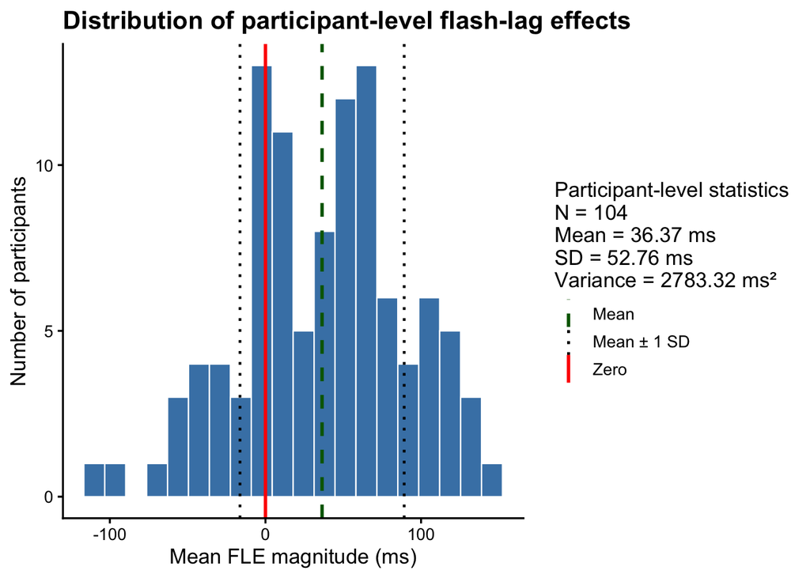

```r
# Calculate one mean FLE magnitude per participant
all_staircase_FLEs_means <- all_staircase_FLEs |>
  group_by(ID) |>
  summarise(
    FLE_ms = mean(FLE_ms, na.rm = TRUE),
    .groups = "drop"
  )

# Descriptive statistics
fle_stats <- all_staircase_FLEs_means |>
  summarise(
    n = sum(!is.na(FLE_ms)),
    mean = mean(FLE_ms, na.rm = TRUE),
    sd = sd(FLE_ms, na.rm = TRUE),
    variance = var(FLE_ms, na.rm = TRUE)
  )

mean_fle <- fle_stats$mean
sd_fle   <- fle_stats$sd

legend_title <- paste0(
  "Participant-level statistics\n",
  "N = ", fle_stats$n, "\n",
  "Mean = ", round(mean_fle, 2), " ms\n",
  "SD = ", round(sd_fle, 2), " ms\n",
  "Variance = ", round(fle_stats$variance, 2), " ms²"
)

ggplot(all_staircase_FLEs_means, aes(x = FLE_ms)) +
  geom_histogram(
    bins = 20,
    fill = "steelblue",
    colour = "white",
    linewidth = 0.4
  ) +

  # Zero
  geom_vline(
    aes(xintercept = 0, linetype = "Zero"),
    colour = "red",
    linewidth = 1
  ) +

  # Mean
  geom_vline(
    aes(xintercept = mean_fle, linetype = "Mean"),
    colour = "darkgreen",
    linewidth = 1
  ) +

  # Mean ± 1 SD
  geom_vline(
    aes(
      xintercept = mean_fle - sd_fle,
      linetype = "Mean ± 1 SD"
    ),
    colour = "black",
    linewidth = 0.8
  ) +
  geom_vline(
    aes(
      xintercept = mean_fle + sd_fle,
      linetype = "Mean ± 1 SD"
    ),
    colour = "black",
    linewidth = 0.8
  ) +

  scale_linetype_manual(
    name = legend_title,
    values = c(
      "Zero" = "solid",
      "Mean" = "dashed",
      "Mean ± 1 SD" = "dotted"
    )
  ) +

  labs(
    title = "Distribution of participant-level flash-lag effects",
    x = "Mean FLE magnitude (ms)",
    y = "Number of participants"
  ) +

  theme_classic(base_size = 13) +
  theme(
    legend.position = "right",
    legend.title = element_text(face = "plain"),
    plot.title = element_text(face = "bold")
  )
```

**FLE (dva) by participant**

```r
#----CHECKING STUF----
n_distinct(all_staircase_FLEs$ID) # no. of IDs
```

```
[1] 104
```

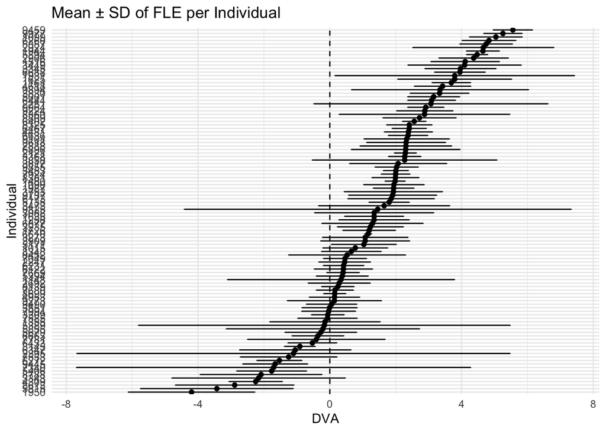

```r
#
all_staircase_FLEs |>
  group_by(ID) |>
  summarise(
    mean_FLE = mean(FLE_dva, na.rm = TRUE),
    sd_FLE = sd(FLE_dva, na.rm = TRUE)
  ) |>
  ggplot(aes(x = reorder(ID, mean_FLE), y = mean_FLE)) +
  geom_point() +
  geom_errorbar(aes(ymin = mean_FLE - sd_FLE, ymax = mean_FLE + sd_FLE), width = 0.2) +
  coord_flip() +
  labs(
    title = "Mean ± SD of FLE per Individual",
    x = "Individual",
    y = "DVA"
  ) +
  geom_hline(yintercept = 0, linetype = "dashed") +
  theme_minimal()
```

#### Visualising negative FLE

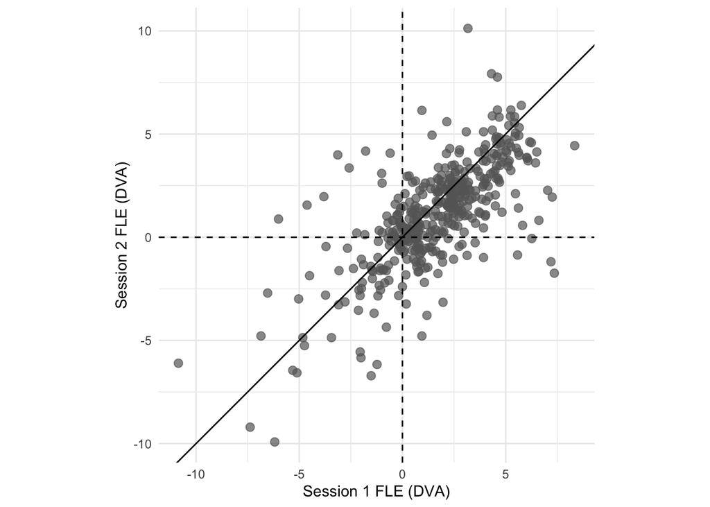

```r
# Make the staircase-level data wide for plotting
wide_staircases <- all_staircase_FLEs |>
  select(ID, session, staircase, FLE_dva) |>
  pivot_wider(
    id_cols = c(ID, staircase),
    names_from = session,
    values_from = FLE_dva,
    names_prefix = "session_"
  )

p <- ggplot(
  wide_staircases,
  aes(x = session_1, y = session_2)
) +
  geom_point(
    color = "grey40",
    size = 2.5,
    alpha = 0.7
  ) +
  geom_abline(
    slope = 1,
    intercept = 0,
    color = "black",
    linetype = "solid"
  ) +
  geom_vline(
    xintercept = 0,
    linetype = "dashed"
  ) +
  geom_hline(
    yintercept = 0,
    linetype = "dashed"
  ) +
  coord_equal() +
  labs(
    x = "Session 1 FLE (DVA)",
    y = "Session 2 FLE (DVA)"
  ) +
  theme_minimal()
p
```

```r
# ggsave(
#   "FLE_session_scatter.png",
#   plot = p,
#   width = 10,
#   height = 8,
#   dpi = 300
# )
```

## Linear Assumptions

To investigate whether each session significantly affects FLE, we fitted a mixed-effects model. In our example, we are looking specifically at the `session` as a *fixed effect* and `ID` as a *random intercept*.

Before commencing with and interpreting the analyses, we need to check if the linear model assumptions are being met:

1. **Independence of observations**

*Repeated measures*; same participant’s FLE measured multiple times under same conditions. Individual particiapnts (`ID`) are independent.

2. **Homoscedasticity**

3. **Normality**

4. **Sample size**

**FLE Histogram**

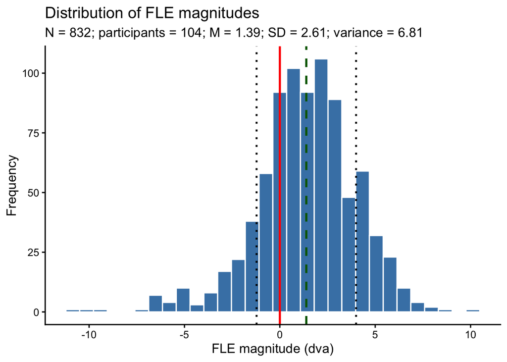

```r
# model
FLE_hierarchical <- lmer(
  FLE_dva ~ session +
    (1 | ID) +
    (1 | ID:session),
  data = all_staircase_FLEs
)

# descrip stats
fle_mean <- mean(all_staircase_FLEs$FLE_dva, na.rm = TRUE)
fle_sd   <- sd(all_staircase_FLEs$FLE_dva, na.rm = TRUE)

# fitted values and residuals
FLE_diagnostics <- data.frame(
  fitted = fitted(FLE_hierarchical),
  residual = resid(FLE_hierarchical, type = "pearson")
)

FLE_histogram <- ggplot(
  all_staircase_FLEs,
  aes(x = FLE_dva)
) +
  geom_histogram(
    bins = 30,
    fill = "steelblue",
    colour = "white"
  ) +
  geom_vline(
    xintercept = 0,
    colour = "red",
    linewidth = 1
  ) +
  geom_vline(
    xintercept = fle_mean,
    colour = "darkgreen",
    linetype = "dashed",
    linewidth = 1
  ) +
  geom_vline(
    xintercept = c(fle_mean - fle_sd, fle_mean + fle_sd),
    colour = "black",
    linetype = "dotted",
    linewidth = 0.9
  ) +
  labs(
    title = "Distribution of FLE magnitudes",
    subtitle = paste0(
      "N = ", nrow(all_staircase_FLEs),
      "; participants = ", n_distinct(all_staircase_FLEs$ID),
      "; M = ", round(fle_mean, 2),
      "; SD = ", round(fle_sd, 2),
      "; variance = ", round(fle_sd^2, 2)
    ),
    x = "FLE magnitude (dva)",
    y = "Frequency"
  ) +
  theme_classic(base_size = 13)

FLE_histogram
```

**Q-Q Plot**

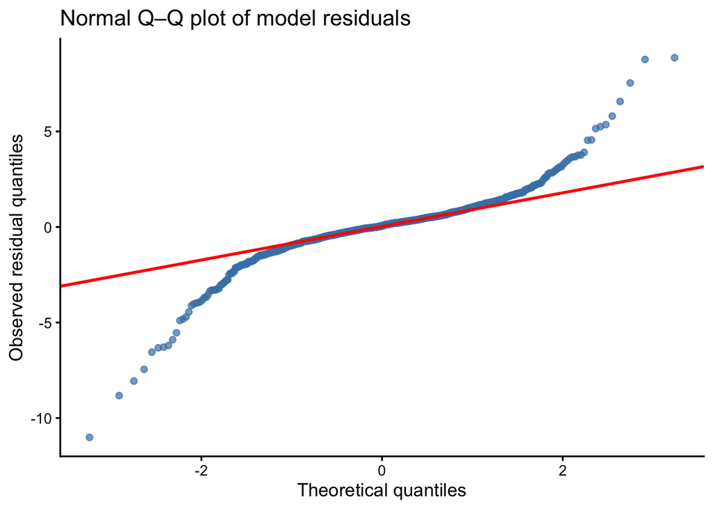

```r
FLE_qqplot <- ggplot(
  FLE_diagnostics,
  aes(sample = residual)
) +
  stat_qq(
    colour = "steelblue",
    alpha = 0.7
  ) +
  stat_qq_line(
    colour = "red",
    linewidth = 1
  ) +
  labs(
    title = "Normal Q–Q plot of model residuals",
    x = "Theoretical quantiles",
    y = "Observed residual quantiles"
  ) +
  theme_classic(base_size = 13)

FLE_qqplot
```

**Residual Plot**

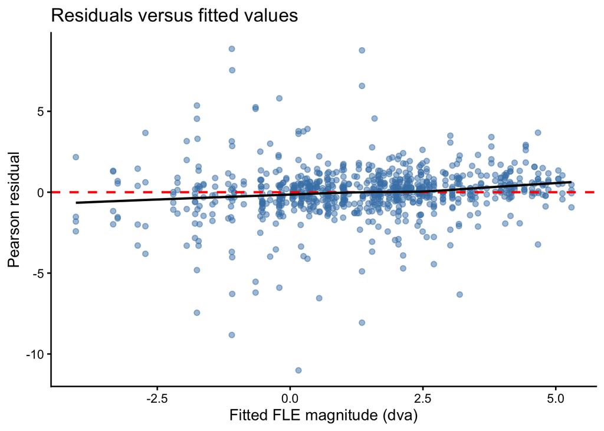

```r
FLE_residual_plot <- ggplot(
  FLE_diagnostics,
  aes(x = fitted, y = residual)
) +
  geom_point(
    colour = "steelblue",
    alpha = 0.5
  ) +
  geom_hline(
    yintercept = 0,
    colour = "red",
    linetype = "dashed",
    linewidth = 0.9
  ) +
  geom_smooth(
    method = "loess",
    formula = y ~ x,
    se = FALSE,
    colour = "black",
    linewidth = 0.9
  ) +
  labs(
    title = "Residuals versus fitted values",
    x = "Fitted FLE magnitude (dva)",
    y = "Pearson residual"
  ) +
  theme_classic(base_size = 13)

FLE_residual_plot
```

## Linear Mixed Model (LMM)

1. Is there stable between-individual variance in FLE?
2. Do some individuals reliably show FLE < 0, and is that pattern stable across sessions?

Separate true between-person variability from measurement noise Allow inference about the probability of negative effects, not just mean differences

**Core Model**

$FLE_{ijk} = \beta_0 + \mu_0i + \epsilon_{ijk}$

Where:

- $i=$ participant
- $j=$ session (1 or 2)
- $k=$ staircase (1-4, 4 per session)
- $\mu_0i=$ participant-specific mean deviation
- $\epsilon_{ijk}=$ within-participant noise

Model assumes: - $\mu_0i \sim \mathcal{N}(0, \sigma^2_{participant})$ - $\epsilon_{ijk} \sim \mathcal{N}(0, \sigma^2_{residual})$

Session and staircase not explicitly inclded, so only 2 sources of variance in this model: $\sigma^2_{total}=\sigma^2_{participant}+\sigma^2_{residual}$

```r
# core lmm
FLE_corelmm <- lmer(FLE_dva ~ 1 + (1 | ID), data = all_staircase_FLEs)
# overall mean FLE and confidence interval
model_parameters(FLE_corelmm)
```

```
# Fixed Effects

Parameter   | Coefficient |   SE |       95% CI | t(829) |      p
-----------------------------------------------------------------
(Intercept) |        1.39 | 0.20 | [1.00, 1.78] |   7.03 | < .001

# Random Effects

Parameter          | Coefficient |   SE |       95% CI
------------------------------------------------------
SD (Intercept: ID) |        1.91 | 0.15 | [1.64, 2.23]
SD (Residual)      |        1.78 | 0.05 | [1.69, 1.88]
```

```
Uncertainty intervals (equal-tailed) and p-values (two-tailed) computed
  using a Wald t-distribution approximation.
```

```r
# variance components and ICC
icc(FLE_corelmm)
```

```
# Intraclass Correlation Coefficient

    Adjusted ICC: 0.535
  Unadjusted ICC: 0.535
```

**Primary Model**

$FLE_{ijk} = \beta_0 + \beta_1Session_j+ \mu_0i + \epsilon_{ijk}$

Same as core model, except now we include $Session$, where $\beta1$ is the population-average difference between Session2 and Session 1.

```r
# Participant random intercept with session as a fixed effect
FLE_lmm <- lmer(
  FLE_dva ~ session + (1 | ID),
  data = all_staircase_FLEs
)
model_parameters(FLE_lmm)
```

```
# Fixed Effects

Parameter   | Coefficient |   SE |         95% CI | t(828) |      p
-------------------------------------------------------------------
(Intercept) |        1.64 | 0.21 | [ 1.23,  2.05] |   7.93 | < .001
session [2] |       -0.50 | 0.12 | [-0.74, -0.26] |  -4.11 | < .001

# Random Effects

Parameter          | Coefficient |   SE |       95% CI
------------------------------------------------------
SD (Intercept: ID) |        1.91 | 0.15 | [1.65, 2.23]
SD (Residual)      |        1.76 | 0.05 | [1.68, 1.86]
```

```
Uncertainty intervals (equal-tailed) and p-values (two-tailed) computed
  using a Wald t-distribution approximation.
```

**Findings:**

**Random Slopes Model**

Key model: $FLE_{ijk} = \beta_0 + \beta_1 Session_j + \mu_i + v_{ij} + \epsilon_{ijk}$

Also same as primary model, but with some additions:

- $v_{ij}=$ session-specific deviation for session $j$ within participant $i$
- $v_{ij} \sim \mathcal{N}(0, \sigma^2_{session})$

Variance is partitioned as such:

$\sigma^2_{total}=\sigma^2_{participant}+\sigma^2_{session}+\sigma^2_{residual}$

```r
# works only with staircase data (8 repeated-measures)
FLE_hierarchical <- lmer(
  FLE_dva ~ session +
    (1 | ID) +
    (1 | ID:session),
  data = all_staircase_FLEs
)

model_parameters(FLE_hierarchical)
```

```
# Fixed Effects

Parameter   | Coefficient |   SE |         95% CI | t(827) |      p
-------------------------------------------------------------------
(Intercept) |        1.64 | 0.21 | [ 1.23,  2.05] |   7.86 | < .001
session [2] |       -0.50 | 0.13 | [-0.77, -0.24] |  -3.72 | < .001

# Random Effects

Parameter                  | Coefficient |   SE |       95% CI
--------------------------------------------------------------
SD (Intercept: ID:session) |        0.44 | 0.16 | [0.22, 0.88]
SD (Intercept: ID)         |        1.89 | 0.15 | [1.62, 2.21]
SD (Residual)              |        1.73 | 0.05 | [1.64, 1.83]
```

```
Uncertainty intervals (equal-tailed) and p-values (two-tailed) computed
  using a Wald t-distribution approximation.
```

```r
icc(FLE_hierarchical)
```

```
# Intraclass Correlation Coefficient

    Adjusted ICC: 0.558
  Unadjusted ICC: 0.553
```

```r
performance(FLE_hierarchical)
```

```
# Indices of model performance

AIC    |   AICc |    BIC | R2 (cond.) | R2 (marg.) |   ICC |  RMSE | Sigma
--------------------------------------------------------------------------
3558.2 | 3558.3 | 3581.9 |      0.562 |      0.009 | 0.558 | 1.605 | 1.731
```

Interpetation:

- FLE magnitude decreased from Session 1 to Session 2 on average by 0.5 dva.
- Participant-level (aka individual differences) SD was *1.89 dva*.
- Session-level SD was *0.44 dva*.
- Staircase-level SD was *1.73 dva*.
- Approximately *52.9%* of the total variance was attributable to stable participant differences (aka individual differences).

**Model performance**

- Marginal $R^2=.009$
- Conditional $R^2=.562$
- RMSE $=1.61$dva

Note to self: calculate AIC and BIC

# Bayesian Model

**Plain english:**

- Each observed FLE is a noisy measurement of a participant’s true FLE
- Participants have different true FLE values
- Those true FLE values come from a population distribution
- We want to estimate how much of that population lies below zero (i.e. proportion of true negative FLE)

While the model gives an estimate proportion of “negative FLE” people, we still don’t know if this proportion is actually greater than 0.

To test whether this proportion is *credibly greater than 0*, we will fit a Bayesian hierarchical model.

Following the standard hierarchical model structure for individual differences, we define the following model:

$$\begin{aligned}
y_{ij} & \sim \mathcal{N}(\theta_i, \sigma_\epsilon) \\
\theta_i & \sim \mathcal{N}(\mu_\theta, \sigma_\theta) \\ \\
\mu_\theta & \sim \log \mathcal{N}(a_\mu, b_\mu) \\ \\
\sigma_\theta & = -\mu_\theta / \Phi^{-1}(0.5 \; p(\theta_i<0)) \\
p(\theta_i<0) & = \Phi(p^{*}_{\theta_i<0}) \\
p^{*}(\theta_i<0) & \sim \mathcal{N}(a_p, b_p) \\ \\
\sigma_\epsilon^2 & \propto 1/\sigma_\epsilon^2
\end{aligned}$$

**Model:**

- $y_ij$ is the observed FLE for participant $i$ in session $j$.
- $\theta_i$ is participant $i$’s underlying FLE (inferred from their 2 sessions)
- $\sigma_\epsilon$ is the *within-participant* error (e.g. test-retest, measurement error)
- $\mu_\theta$ is the *average FLE* in population. So if $\mu_\theta>0$, then the average person has a positive FLE.
- $\sigma_\theta$ is how much true FLE differs between participants (i.e. true individual differences). This is the population-level spread of true participant effects (assumption of normal distribution).
  - Small $\sigma_\theta$ –> people are similar
  - Large $\sigma_\theta$ –> people vary a lot
  - Significantly large $\sigma_\theta$ –> negative FLE indivduals are plausible

We parameterize the individual differences standard deviation $\sigma_\theta$ in terms of the proportion of individuals that show a negative FLE (i.e., a flash *lead* effect, $p(\theta_i<0)$) to directly estimate this quantity of interest.

**What this does:**

- $p(\theta_i<0)$ (proportion of negative FLE) becomes the parameter of interest.
- Instead of estimating variance from the data to derive proportion, we estimate proportion to derive variance.

We also place a log-normal prior on the *group mean* $\mu_\theta$ to ensure positive values (but we could replace this by something more flexible).

> This prior means that we assume the average FLE is positive.

**Probit for Sampling Efficiency:** To improve sampling efficiency, we place a normal prior on the probit-transformed quantity $p^{*}(\theta_i<0)$.

> Probit model is a type of regression used to model a binary outcome. Probabilities (0-1) are hard to sample directly, but -infinity to infinity is easier. So, we sample in probit space and transform back to probability.

Finally, we place a non-informative prior on the error variance $\sigma_\epsilon^2$.